# ESM_201_Assignment_1

Sandra Fogg

2/3/2019

## Question 1

### A. Describe how annual population data are used to calculate $\frac{dN}{Ndt}$.

The expression $\frac{dN}{Ndt}$ represents the per capita rate change of a population (r) at time t. By taking the natural log of the annual population at time (t+1), dividing it by the initial number of individuals in the same population at time (t), and multiplying it by the expression $\frac{1}{(t+1)-t}$, the annual population data can be used to estimate per capita rate of change of the population. In this case, the time difference is 1 year, so the second term of the equation is equal to 1.

### B. Provide the calculation used to determine $\frac{dN}{Ndt}$ for each country during the time period 1963 to 1964.

##### Brazil, $r= ln\left(\frac{81972001}{79602001}\right)$

##### India, $r= ln\left(\frac{486639001}{476632001}\right)$

##### Japan, $r= ln\left(\frac{96959001}{95929001}\right)$

##### Mexico, $r= ln\left(\frac{43052001}{41715001}\right)$

##### South Korea, $r= ln\left(\frac{27767001}{27138001}\right)$

Calculated vs. Actual Per Capita Rate of Population Change by Country from 1963 to 1964

| Country | Calculated dN/Ndt | Actual dN/Ndt |
| --- | --- | --- |
| Brazil | 0.0293 | 0.0293 |
| India | 0.0208 | 0.0208 |
| Japan | 0.0107 | 0.0107 |
| Mexico | 0.0315 | 0.0315 |
| South Korea | 0.0229 | 0.0229 |

The calculated values are exactly the same as the provided values for $\frac{dN}{Ndt}$

### C. Calculate population rate change of India from 1963 - 2004

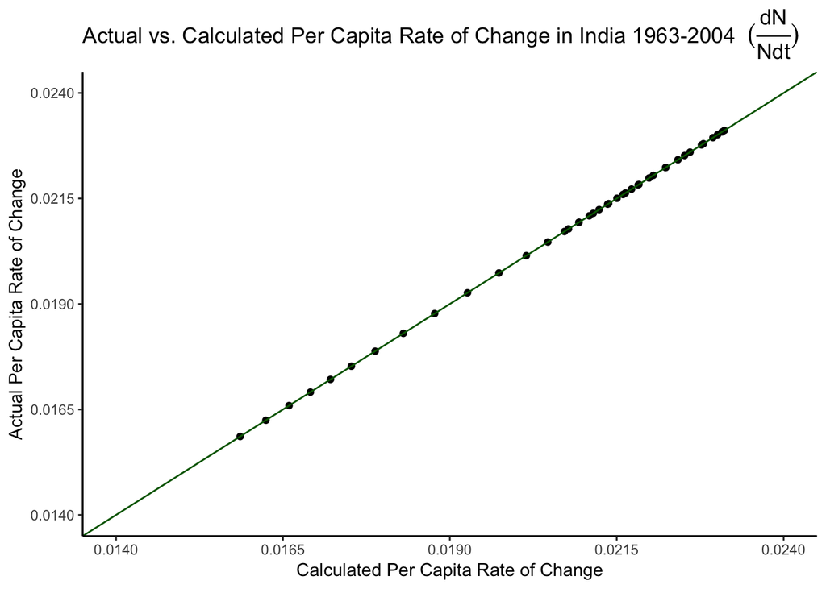

## QUESTION 2

### A. Graph $\frac{dN}{Ndt}$ vs. N<sub>t</sub> for each country

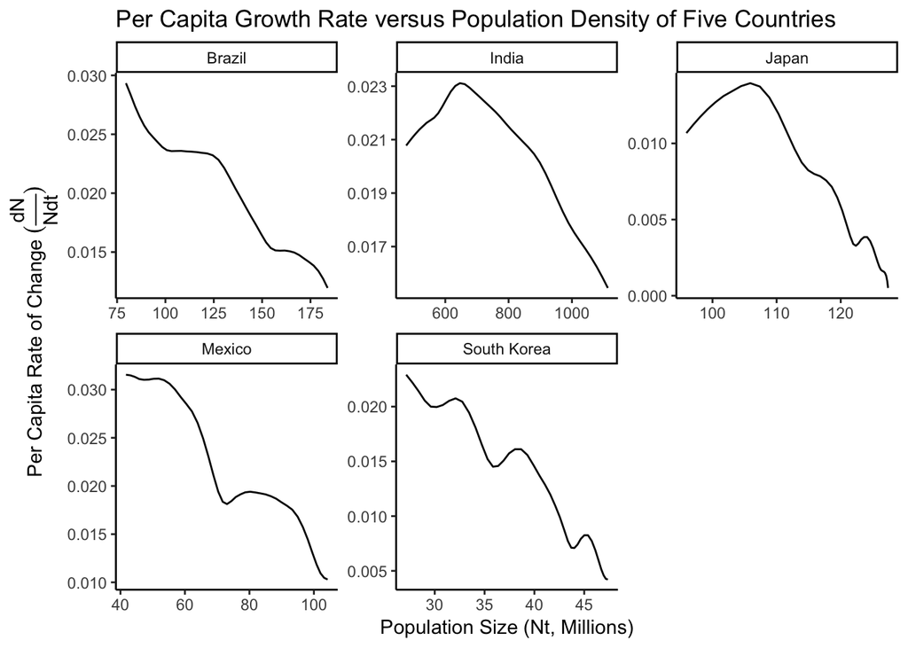

### B. Estimate the carrying capacity for India and Brazil

#### India

##### $Population = 2.252*10^9 - 7.226*10^{10}(\frac{dN}{Ndt})$

##### The carrying capacity (K) when $\frac{dN}{Ndt}$ = 0 is $2.252*10^9$ or 2,252,000,000 people.

#### Brazil

##### $Population = 2.607*10^8 - 6.392*10^9(\frac{dN}{Ndt})$

##### The carrying capacity (K) when $\frac{dN}{Ndt}$ = 0 is $2.607*10^8$ or 260,700,000 people.

### C. Modify the plot to include year and food consumption

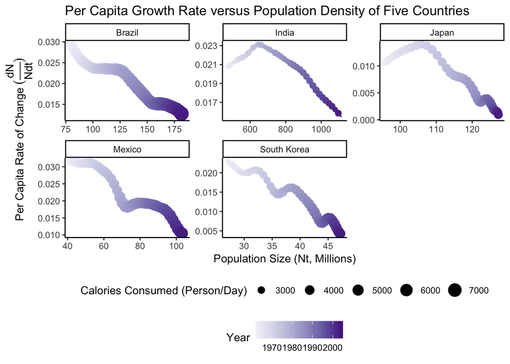

## Question 3

### A. Perform a multilinear regression of education and food consumption for all countries

#### All Countries:

All things other factors remaining constant, for each unit increase in calories per person, per day, $\frac{dN}{Ndt}\$ increases by $1.292*10^{-7}$.

### B. Perform a multilinear regression of education and food consumption for each country

**Linear Regression of Education and Food Consumption Results**

|  | *Dependent variable:* |  |  |  |  |  |
| --- | --- | --- | --- | --- | --- | --- |
|  | Per Capita Rate of Change (dN/Ndt) |  |  |  |  |  |
|  | All | Brazil | India | Japan | Mexico | South Korea |
|  | (1) | (2) | (3) | (4) | (5) | (6) |
| Years of Education | -0.002249*** | -0.002420*** | -0.001523*** | -0.003834*** | -0.002280*** | -0.002757*** |
|  | (0.000087) | (0.000343) | (0.000287) | (0.000254) | (0.000260) | (0.000357) |
| Calories Consumed Per Person Per Day | 0.0000001 | -0.000001** | -0.0000004 | -0.000002** | -0.000005*** | -0.0000004 |
|  | (0.0000002) | (0.000001) | (0.000002) | (0.000001) | (0.000001) | (0.000001) |
| Constant | 0.029747*** | 0.036311*** | 0.026005*** | 0.050606*** | 0.058878*** | 0.038582*** |
|  | (0.000983) | (0.001930) | (0.003791) | (0.002796) | (0.002154) | (0.001146) |
| Observations | 205 | 41 | 41 | 41 | 41 | 41 |
| R<sup>2</sup> | 0.770283 | 0.925976 | 0.618512 | 0.915060 | 0.963831 | 0.951823 |
| Adjusted R<sup>2</sup> | 0.768008 | 0.922080 | 0.598434 | 0.910590 | 0.961928 | 0.949287 |
| Residual Std. Error | 0.003665 (df = 202) | 0.001333 (df = 38) | 0.001320 (df = 38) | 0.001327 (df = 38) | 0.001305 (df = 38) | 0.001285 (df = 38) |
| F Statistic | 338.670700*** (df = 2; 202) | 237.673500*** (df = 2; 38) | 30.804970*** (df = 2; 38) | 204.688500*** (df = 2; 38) | 506.316300*** (df = 2; 38) | 375.379000*** (df = 2; 38) |
| *Note:* | p<0.1; p<0.05; p<0.01 |  |  |  |  |  |

#### Brazil:

Based on the linear regression $\frac{dN}{Ndt}\$ = $3.631*10^{-2}$ - $1.150*10^{-6}$(Calories (Person/Day)) - $2.420*10^{-3}$(Years Educated), education level is a significant predicator of per capita population growth rate (p<0.001). Food consumption, though less impactful than education, also has a significant (p<0.05) effect on $\frac{dN}{Ndt}\$.

All other factors remaining constant, for each unit increase in education level, $\frac{dN}{Ndt}\$ decreases by $2.420*10^{-3}$.

All things other factors remaining constant, for each unit increase in calories per person, per day, $\frac{dN}{Ndt}\$ decreases by $1.150*10^{-6}$.

#### India

Based on the linear regression $\frac{dN}{Ndt}\$ = $2.600*10^{-2}$ - $4.433*10^{-7}$(Calories (Person/Day)) - $1.523*10^{-3}$(Years Educated), education level is a significant predicator of per capita population growth rate (p<0.001). Food consumption, does not have a significant (p<0.05) effect on $\frac{dN}{Ndt}\$ (p=0.793).

All other factors remaining constant, for each unit increase in education level, $\frac{dN}{Ndt}\$ decreases by $1.523*10^{-3}$.

#### Japan:

Based on the linear regression $\frac{dN}{Ndt}\$ = $5.061*10^{-2}$ - $1.978*10^{-6}$(Calories (Person/Day)) - $3.834*10^{-3}$(Years Educated), education level is a significant predicator of per capita population growth rate (p<0.001). Food consumption, also has a significant effect on $\frac{dN}{Ndt}\$ (p<0.05).

All other factors remaining constant, for each unit increase in education level, $\frac{dN}{Ndt}\$ decreases by $3.834*10^{-3}$.

All other factors remaining constant, for each unit increase in calories per person, per day, $\frac{dN}{Ndt}\$ decreases by $1.978*10^{-6}$.

#### Mexico:

Based on the linear regression $\frac{dN}{Ndt}\$ = $5.888*10^{-2}$ - $5.306*10^{-6}$(Calories (Person/Day)) - $2.280*10^{-3}$(Years Educated), education level is a significant predicator of per capita population growth rate (p<0.001). Calories eaten per person, per day simlilarly has a very significant effect on $\frac{dN}{Ndt}\$ (p<0.001) in Mexico.

All other factors remaining constant, for each unit increase in education level, $\frac{dN}{Ndt}\$ decreases by $2.280*10^{-3}$.

All things other factors remaining constant, for each unit increase in calories per person, per day, $\frac{dN}{Ndt}\$ decreases by $5.306*10^{-6}$.

#### South Korea:

All other factors remaining constant, for each unit increase in education level, $\frac{dN}{Ndt}\$ decreases by $2.757*10^{-3}$.

All other factors remaining constant, for each unit increase in calories per person, per day, $\frac{dN}{Ndt}\$ decreases by $4.279*10^{-7}$.